# Risk Factor Analysis

## Outcome Variable

**Outcome Variable:** pers_wasted624

## Predictor Variables

**Intervention Variable:** ever_co06

**Adjustment Set:**

unadjusted

## Stratifying Variables

The analysis was stratified on these variable(s):

- studyid
- country

## Data Summary

| studyid | country | ever_co06 | pers_wasted624 | n_cell | n |
| --- | --- | --- | --- | --- | --- |
| ki0047075b-MAL-ED | BANGLADESH | 0 | 0 | 215 | 239 |
| ki0047075b-MAL-ED | BANGLADESH | 0 | 1 | 16 | 239 |
| ki0047075b-MAL-ED | BANGLADESH | 1 | 0 | 6 | 239 |
| ki0047075b-MAL-ED | BANGLADESH | 1 | 1 | 2 | 239 |
| ki0047075b-MAL-ED | BRAZIL | 0 | 0 | 200 | 202 |
| ki0047075b-MAL-ED | BRAZIL | 0 | 1 | 2 | 202 |
| ki0047075b-MAL-ED | BRAZIL | 1 | 0 | 0 | 202 |
| ki0047075b-MAL-ED | BRAZIL | 1 | 1 | 0 | 202 |
| ki0047075b-MAL-ED | INDIA | 0 | 0 | 196 | 234 |
| ki0047075b-MAL-ED | INDIA | 0 | 1 | 21 | 234 |
| ki0047075b-MAL-ED | INDIA | 1 | 0 | 10 | 234 |
| ki0047075b-MAL-ED | INDIA | 1 | 1 | 7 | 234 |
| ki0047075b-MAL-ED | NEPAL | 0 | 0 | 227 | 234 |
| ki0047075b-MAL-ED | NEPAL | 0 | 1 | 1 | 234 |
| ki0047075b-MAL-ED | NEPAL | 1 | 0 | 5 | 234 |
| ki0047075b-MAL-ED | NEPAL | 1 | 1 | 1 | 234 |
| ki0047075b-MAL-ED | PERU | 0 | 0 | 261 | 264 |
| ki0047075b-MAL-ED | PERU | 0 | 1 | 2 | 264 |
| ki0047075b-MAL-ED | PERU | 1 | 0 | 1 | 264 |
| ki0047075b-MAL-ED | PERU | 1 | 1 | 0 | 264 |
| ki0047075b-MAL-ED | SOUTH AFRICA | 0 | 0 | 252 | 258 |
| ki0047075b-MAL-ED | SOUTH AFRICA | 0 | 1 | 2 | 258 |
| ki0047075b-MAL-ED | SOUTH AFRICA | 1 | 0 | 4 | 258 |
| ki0047075b-MAL-ED | SOUTH AFRICA | 1 | 1 | 0 | 258 |
| ki0047075b-MAL-ED | TANZANIA, UNITED REPUBLIC OF | 0 | 0 | 240 | 244 |
| ki0047075b-MAL-ED | TANZANIA, UNITED REPUBLIC OF | 0 | 1 | 0 | 244 |
| ki0047075b-MAL-ED | TANZANIA, UNITED REPUBLIC OF | 1 | 0 | 4 | 244 |
| ki0047075b-MAL-ED | TANZANIA, UNITED REPUBLIC OF | 1 | 1 | 0 | 244 |
| ki1000108-CMC-V-BCS-2002 | INDIA | 0 | 0 | 315 | 368 |
| ki1000108-CMC-V-BCS-2002 | INDIA | 0 | 1 | 22 | 368 |

[output cut: 118 more lines]

The following strata were considered:

- studyid: ki0047075b-MAL-ED, country: BANGLADESH
- studyid: ki0047075b-MAL-ED, country: BRAZIL
- studyid: ki0047075b-MAL-ED, country: INDIA
- studyid: ki0047075b-MAL-ED, country: NEPAL
- studyid: ki0047075b-MAL-ED, country: PERU
- studyid: ki0047075b-MAL-ED, country: SOUTH AFRICA
- studyid: ki0047075b-MAL-ED, country: TANZANIA, UNITED REPUBLIC OF
- studyid: ki1000108-CMC-V-BCS-2002, country: INDIA
- studyid: ki1000108-IRC, country: INDIA
- studyid: ki1000109-EE, country: PAKISTAN
- studyid: ki1000109-ResPak, country: PAKISTAN
- studyid: ki1000304-VITAMIN-A, country: INDIA
- studyid: ki1000304b-SAS-CompFeed, country: INDIA
- studyid: ki1000304b-SAS-FoodSuppl, country: INDIA
- studyid: ki1017093-NIH-Birth, country: BANGLADESH
- studyid: ki1017093b-PROVIDE, country: BANGLADESH
- studyid: ki1017093c-NIH-Crypto, country: BANGLADESH
- studyid: ki1066203-TanzaniaChild2, country: TANZANIA, UNITED REPUBLIC OF
- studyid: ki1101329-Keneba, country: GAMBIA
- studyid: ki1112895-Burkina Faso Zn, country: BURKINA FASO
- studyid: ki1112895-Guatemala BSC, country: GUATEMALA
- studyid: ki1113344-GMS-Nepal, country: NEPAL
- studyid: ki1114097-CMIN, country: BANGLADESH
- studyid: ki1114097-CMIN, country: BRAZIL
- studyid: ki1114097-CMIN, country: GUINEA-BISSAU
- studyid: ki1114097-CMIN, country: PERU
- studyid: ki1114097-CONTENT, country: PERU
- studyid: ki1119695-PROBIT, country: BELARUS
- studyid: ki1126311-ZVITAMBO, country: ZIMBABWE
- studyid: ki1135781-COHORTS, country: GUATEMALA
- studyid: ki1135781-COHORTS, country: INDIA
- studyid: ki1135781-COHORTS, country: PHILIPPINES
- studyid: ki1148112-iLiNS-DOSE, country: MALAWI
- studyid: ki1148112-iLiNS-DYAD-M, country: MALAWI
- studyid: ki1148112-LCNI-5, country: MALAWI
- studyid: kiGH5241-JiVitA-3, country: BANGLADESH
- studyid: kiGH5241-JiVitA-4, country: BANGLADESH

### Dropped Strata

Some strata were dropped due to rare outcomes:

- studyid: ki0047075b-MAL-ED, country: BANGLADESH
- studyid: ki0047075b-MAL-ED, country: BRAZIL
- studyid: ki0047075b-MAL-ED, country: NEPAL
- studyid: ki0047075b-MAL-ED, country: PERU
- studyid: ki0047075b-MAL-ED, country: SOUTH AFRICA
- studyid: ki0047075b-MAL-ED, country: TANZANIA, UNITED REPUBLIC OF
- studyid: ki1000109-ResPak, country: PAKISTAN
- studyid: ki1017093c-NIH-Crypto, country: BANGLADESH
- studyid: ki1112895-Burkina Faso Zn, country: BURKINA FASO
- studyid: ki1112895-Guatemala BSC, country: GUATEMALA
- studyid: ki1114097-CMIN, country: BRAZIL
- studyid: ki1114097-CMIN, country: GUINEA-BISSAU
- studyid: ki1114097-CMIN, country: PERU
- studyid: ki1114097-CONTENT, country: PERU
- studyid: ki1119695-PROBIT, country: BELARUS
- studyid: ki1135781-COHORTS, country: GUATEMALA
- studyid: ki1148112-iLiNS-DOSE, country: MALAWI
- studyid: ki1148112-iLiNS-DYAD-M, country: MALAWI
- studyid: ki1148112-LCNI-5, country: MALAWI

## Methods Detail

We’re interested in the causal parameters $E[Y_a]$ for all values of $a \in \mathcal{A}$. These parameters represent the mean outcome if, possibly contrary to fact, we intervened to set all units to have $A=a$. Under the randomization and positivity assumptions, these are identified by the statistical parameters $\psi_a=E_W[E_{Y|A,W}(Y|A=a,W)]$. In addition, we’re interested in the mean of $Y$, $E[Y]$ under no intervention (the observed mean). We will estimate these parameters by using SuperLearner to fit the relevant likelihood factors – $E_{Y|A,W}(Y|A=a,W)$ and $p(A=a|W)$, and then updating our likelihood fit using a joint TMLE.

For unadjusted analyses ($W=\{\}$), initial likelihoods were estimated using Lrnr_glm to estimate the simple $E(Y|A)$ and Lrnr_mean to estimate $p(A)$. For adjusted analyses, a small library containing Lrnr_glmnet, Lrnr_xgboost, and Lrnr_mean was used.

Having estimated these parameters, we will then use the delta method to estimate relative risks and attributable risks relative to a prespecified baseline level of $A$.

# Results Detail

## Results Plots

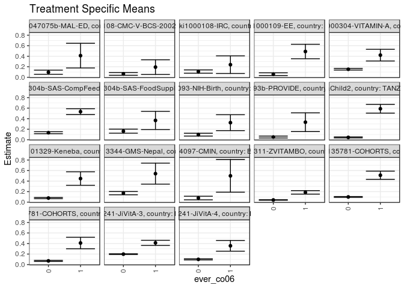

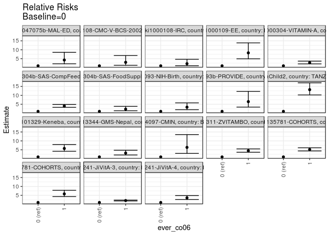

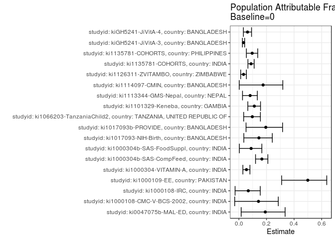

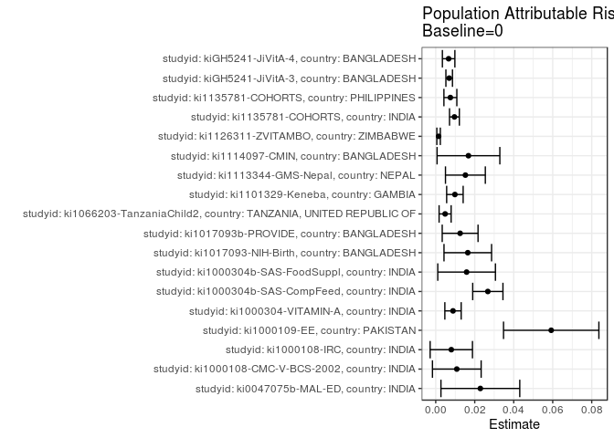

## Results Table

### Parameter: TSM

| studyid | country | intervention_level | baseline_level | estimate | ci_lower | ci_upper |
| --- | --- | --- | --- | --- | --- | --- |
| ki0047075b-MAL-ED | INDIA | 0 | NA | 0.0967742 | 0.0573533 | 0.1361951 |
| ki0047075b-MAL-ED | INDIA | 1 | NA | 0.4117647 | 0.1773128 | 0.6462166 |
| ki1000108-CMC-V-BCS-2002 | INDIA | 0 | NA | 0.0652819 | 0.0388724 | 0.0916914 |
| ki1000108-CMC-V-BCS-2002 | INDIA | 1 | NA | 0.1935484 | 0.0542834 | 0.3328134 |
| ki1000108-IRC | INDIA | 0 | NA | 0.1093750 | 0.0781199 | 0.1406301 |
| ki1000108-IRC | INDIA | 1 | NA | 0.2400000 | 0.0723815 | 0.4076185 |
| ki1000109-EE | PAKISTAN | 0 | NA | 0.0593750 | 0.0334470 | 0.0853030 |
| ki1000109-EE | PAKISTAN | 1 | NA | 0.4901961 | 0.3528123 | 0.6275799 |
| ki1000304-VITAMIN-A | INDIA | 0 | NA | 0.1528777 | 0.1379181 | 0.1678373 |
| ki1000304-VITAMIN-A | INDIA | 1 | NA | 0.4210526 | 0.3100269 | 0.5320783 |
| ki1000304b-SAS-CompFeed | INDIA | 0 | NA | 0.1337580 | 0.1145801 | 0.1529358 |
| ki1000304b-SAS-CompFeed | INDIA | 1 | NA | 0.5333333 | 0.4788565 | 0.5878101 |
| ki1000304b-SAS-FoodSuppl | INDIA | 0 | NA | 0.1629213 | 0.1245101 | 0.2013326 |
| ki1000304b-SAS-FoodSuppl | INDIA | 1 | NA | 0.3666667 | 0.1940023 | 0.5393310 |
| ki1017093-NIH-Birth | BANGLADESH | 0 | NA | 0.0968421 | 0.0702202 | 0.1234641 |
| ki1017093-NIH-Birth | BANGLADESH | 1 | NA | 0.3243243 | 0.1733404 | 0.4753082 |
| ki1017093b-PROVIDE | BANGLADESH | 0 | NA | 0.0516351 | 0.0336266 | 0.0696436 |
| ki1017093b-PROVIDE | BANGLADESH | 1 | NA | 0.3333333 | 0.1553754 | 0.5112913 |
| ki1066203-TanzaniaChild2 | TANZANIA, UNITED REPUBLIC OF | 0 | NA | 0.0446429 | 0.0352105 | 0.0540752 |
| ki1066203-TanzaniaChild2 | TANZANIA, UNITED REPUBLIC OF | 1 | NA | 0.5882353 | 0.5053994 | 0.6710711 |
| ki1101329-Keneba | GAMBIA | 0 | NA | 0.0780809 | 0.0666736 | 0.0894883 |
| ki1101329-Keneba | GAMBIA | 1 | NA | 0.4482759 | 0.3202590 | 0.5762927 |
| ki1113344-GMS-Nepal | NEPAL | 0 | NA | 0.1714286 | 0.1401870 | 0.2026701 |
| ki1113344-GMS-Nepal | NEPAL | 1 | NA | 0.5416667 | 0.3421536 | 0.7411798 |
| ki1114097-CMIN | BANGLADESH | 0 | NA | 0.0788382 | 0.0447469 | 0.1129294 |
| ki1114097-CMIN | BANGLADESH | 1 | NA | 0.5000000 | 0.1894833 | 0.8105167 |
| ki1126311-ZVITAMBO | ZIMBABWE | 0 | NA | 0.0416518 | 0.0373207 | 0.0459830 |
| ki1126311-ZVITAMBO | ZIMBABWE | 1 | NA | 0.1860465 | 0.1528104 | 0.2192827 |
| ki1135781-COHORTS | INDIA | 0 | NA | 0.0990254 | 0.0912880 | 0.1067628 |
| ki1135781-COHORTS | INDIA | 1 | NA | 0.5109489 | 0.4329709 | 0.5889269 |
| ki1135781-COHORTS | PHILIPPINES | 0 | NA | 0.0705009 | 0.0608060 | 0.0801959 |
| ki1135781-COHORTS | PHILIPPINES | 1 | NA | 0.4098361 | 0.3005502 | 0.5191219 |
| kiGH5241-JiVitA-3 | BANGLADESH | 0 | NA | 0.1986187 | 0.1911126 | 0.2061248 |
| kiGH5241-JiVitA-3 | BANGLADESH | 1 | NA | 0.4126638 | 0.3641991 | 0.4611285 |
| kiGH5241-JiVitA-4 | BANGLADESH | 0 | NA | 0.0991415 | 0.0886008 | 0.1096821 |
| kiGH5241-JiVitA-4 | BANGLADESH | 1 | NA | 0.3565891 | 0.2547579 | 0.4584204 |

### Parameter: E(Y)

| studyid | country | intervention_level | baseline_level | estimate | ci_lower | ci_upper |
| --- | --- | --- | --- | --- | --- | --- |
| ki0047075b-MAL-ED | INDIA | NA | NA | 0.1196581 | 0.0779840 | 0.1613323 |
| ki1000108-CMC-V-BCS-2002 | INDIA | NA | NA | 0.0760870 | 0.0489610 | 0.1032130 |
| ki1000108-IRC | INDIA | NA | NA | 0.1173594 | 0.0861296 | 0.1485892 |
| ki1000109-EE | PAKISTAN | NA | NA | 0.1185984 | 0.0856546 | 0.1515422 |
| ki1000304-VITAMIN-A | INDIA | NA | NA | 0.1617391 | 0.1466878 | 0.1767905 |
| ki1000304b-SAS-CompFeed | INDIA | NA | NA | 0.1604755 | 0.1397079 | 0.1812430 |
| ki1000304b-SAS-FoodSuppl | INDIA | NA | NA | 0.1787565 | 0.1404842 | 0.2170288 |
| ki1017093-NIH-Birth | BANGLADESH | NA | NA | 0.1132813 | 0.0858017 | 0.1407608 |
| ki1017093b-PROVIDE | BANGLADESH | NA | NA | 0.0641447 | 0.0446535 | 0.0836359 |
| ki1066203-TanzaniaChild2 | TANZANIA, UNITED REPUBLIC OF | NA | NA | 0.0494534 | 0.0397554 | 0.0591514 |
| ki1101329-Keneba | GAMBIA | NA | NA | 0.0879121 | 0.0760335 | 0.0997906 |
| ki1113344-GMS-Nepal | NEPAL | NA | NA | 0.1866438 | 0.1550166 | 0.2182711 |
| ki1114097-CMIN | BANGLADESH | NA | NA | 0.0956175 | 0.0591654 | 0.1320697 |
| ki1126311-ZVITAMBO | ZIMBABWE | NA | NA | 0.0431105 | 0.0387958 | 0.0474253 |
| ki1135781-COHORTS | INDIA | NA | NA | 0.1086181 | 0.1006662 | 0.1165699 |
| ki1135781-COHORTS | PHILIPPINES | NA | NA | 0.0780116 | 0.0679971 | 0.0880261 |
| kiGH5241-JiVitA-3 | BANGLADESH | NA | NA | 0.2055161 | 0.1979472 | 0.2130849 |
| kiGH5241-JiVitA-4 | BANGLADESH | NA | NA | 0.1057558 | 0.0949876 | 0.1165240 |

### Parameter: RR

| studyid | country | intervention_level | baseline_level | estimate | ci_lower | ci_upper |
| --- | --- | --- | --- | --- | --- | --- |
| ki0047075b-MAL-ED | INDIA | 0 | 0 | 1.000000 | 1.000000 | 1.000000 |
| ki0047075b-MAL-ED | INDIA | 1 | 0 | 4.254902 | 2.112725 | 8.569117 |
| ki1000108-CMC-V-BCS-2002 | INDIA | 0 | 0 | 1.000000 | 1.000000 | 1.000000 |
| ki1000108-CMC-V-BCS-2002 | INDIA | 1 | 0 | 2.964809 | 1.298682 | 6.768476 |
| ki1000108-IRC | INDIA | 0 | 0 | 1.000000 | 1.000000 | 1.000000 |
| ki1000108-IRC | INDIA | 1 | 0 | 2.194286 | 1.031740 | 4.666768 |
| ki1000109-EE | PAKISTAN | 0 | 0 | 1.000000 | 1.000000 | 1.000000 |
| ki1000109-EE | PAKISTAN | 1 | 0 | 8.255934 | 4.913812 | 13.871196 |
| ki1000304-VITAMIN-A | INDIA | 0 | 0 | 1.000000 | 1.000000 | 1.000000 |
| ki1000304-VITAMIN-A | INDIA | 1 | 0 | 2.754180 | 2.078949 | 3.648721 |
| ki1000304b-SAS-CompFeed | INDIA | 0 | 0 | 1.000000 | 1.000000 | 1.000000 |
| ki1000304b-SAS-CompFeed | INDIA | 1 | 0 | 3.987302 | 3.268758 | 4.863797 |
| ki1000304b-SAS-FoodSuppl | INDIA | 0 | 0 | 1.000000 | 1.000000 | 1.000000 |
| ki1000304b-SAS-FoodSuppl | INDIA | 1 | 0 | 2.250575 | 1.329177 | 3.810695 |
| ki1017093-NIH-Birth | BANGLADESH | 0 | 0 | 1.000000 | 1.000000 | 1.000000 |
| ki1017093-NIH-Birth | BANGLADESH | 1 | 0 | 3.349001 | 1.950375 | 5.750590 |
| ki1017093b-PROVIDE | BANGLADESH | 0 | 0 | 1.000000 | 1.000000 | 1.000000 |
| ki1017093b-PROVIDE | BANGLADESH | 1 | 0 | 6.455556 | 3.411812 | 12.214682 |
| ki1066203-TanzaniaChild2 | TANZANIA, UNITED REPUBLIC OF | 0 | 0 | 1.000000 | 1.000000 | 1.000000 |
| ki1066203-TanzaniaChild2 | TANZANIA, UNITED REPUBLIC OF | 1 | 0 | 13.176470 | 10.221764 | 16.985265 |
| ki1101329-Keneba | GAMBIA | 0 | 0 | 1.000000 | 1.000000 | 1.000000 |
| ki1101329-Keneba | GAMBIA | 1 | 0 | 5.741172 | 4.165708 | 7.912473 |
| ki1113344-GMS-Nepal | NEPAL | 0 | 0 | 1.000000 | 1.000000 | 1.000000 |
| ki1113344-GMS-Nepal | NEPAL | 1 | 0 | 3.159722 | 2.094957 | 4.765655 |
| ki1114097-CMIN | BANGLADESH | 0 | 0 | 1.000000 | 1.000000 | 1.000000 |
| ki1114097-CMIN | BANGLADESH | 1 | 0 | 6.342105 | 2.975646 | 13.517164 |
| ki1126311-ZVITAMBO | ZIMBABWE | 0 | 0 | 1.000000 | 1.000000 | 1.000000 |
| ki1126311-ZVITAMBO | ZIMBABWE | 1 | 0 | 4.466706 | 3.632595 | 5.492345 |
| ki1135781-COHORTS | INDIA | 0 | 0 | 1.000000 | 1.000000 | 1.000000 |
| ki1135781-COHORTS | INDIA | 1 | 0 | 5.159776 | 4.346800 | 6.124801 |
| ki1135781-COHORTS | PHILIPPINES | 0 | 0 | 1.000000 | 1.000000 | 1.000000 |
| ki1135781-COHORTS | PHILIPPINES | 1 | 0 | 5.813201 | 4.306406 | 7.847217 |
| kiGH5241-JiVitA-3 | BANGLADESH | 0 | 0 | 1.000000 | 1.000000 | 1.000000 |
| kiGH5241-JiVitA-3 | BANGLADESH | 1 | 0 | 2.077668 | 1.840215 | 2.345762 |
| kiGH5241-JiVitA-4 | BANGLADESH | 0 | 0 | 1.000000 | 1.000000 | 1.000000 |
| kiGH5241-JiVitA-4 | BANGLADESH | 1 | 0 | 3.596771 | 2.658647 | 4.865920 |

### Parameter: PAR

| studyid | country | intervention_level | baseline_level | estimate | ci_lower | ci_upper |
| --- | --- | --- | --- | --- | --- | --- |
| ki0047075b-MAL-ED | INDIA | 0 | NA | 0.0228839 | 0.0026719 | 0.0430960 |
| ki1000108-CMC-V-BCS-2002 | INDIA | 0 | NA | 0.0108051 | -0.0016795 | 0.0232896 |
| ki1000108-IRC | INDIA | 0 | NA | 0.0079844 | -0.0028711 | 0.0188399 |
| ki1000109-EE | PAKISTAN | 0 | NA | 0.0592234 | 0.0347722 | 0.0836745 |
| ki1000304-VITAMIN-A | INDIA | 0 | NA | 0.0088614 | 0.0046730 | 0.0130499 |
| ki1000304b-SAS-CompFeed | INDIA | 0 | NA | 0.0267175 | 0.0189642 | 0.0344709 |
| ki1000304b-SAS-FoodSuppl | INDIA | 0 | NA | 0.0158351 | 0.0010471 | 0.0306231 |
| ki1017093-NIH-Birth | BANGLADESH | 0 | NA | 0.0164391 | 0.0042395 | 0.0286388 |
| ki1017093b-PROVIDE | BANGLADESH | 0 | NA | 0.0125096 | 0.0033225 | 0.0216968 |
| ki1066203-TanzaniaChild2 | TANZANIA, UNITED REPUBLIC OF | 0 | NA | 0.0048106 | 0.0017235 | 0.0078976 |
| ki1101329-Keneba | GAMBIA | 0 | NA | 0.0098312 | 0.0056022 | 0.0140602 |
| ki1113344-GMS-Nepal | NEPAL | 0 | NA | 0.0152153 | 0.0049943 | 0.0254362 |
| ki1114097-CMIN | BANGLADESH | 0 | NA | 0.0167794 | 0.0006811 | 0.0328776 |
| ki1126311-ZVITAMBO | ZIMBABWE | 0 | NA | 0.0014587 | 0.0005664 | 0.0023510 |
| ki1135781-COHORTS | INDIA | 0 | NA | 0.0095926 | 0.0070711 | 0.0121142 |
| ki1135781-COHORTS | PHILIPPINES | 0 | NA | 0.0075107 | 0.0041943 | 0.0108271 |
| kiGH5241-JiVitA-3 | BANGLADESH | 0 | NA | 0.0068974 | 0.0052099 | 0.0085849 |
| kiGH5241-JiVitA-4 | BANGLADESH | 0 | NA | 0.0066144 | 0.0034149 | 0.0098139 |

### Parameter: PAF

| studyid | country | intervention_level | baseline_level | estimate | ci_lower | ci_upper |
| --- | --- | --- | --- | --- | --- | --- |
| ki0047075b-MAL-ED | INDIA | 0 | NA | 0.1912442 | 0.0163422 | 0.3350473 |
| ki1000108-CMC-V-BCS-2002 | INDIA | 0 | NA | 0.1420093 | -0.0305521 | 0.2856761 |
| ki1000108-IRC | INDIA | 0 | NA | 0.0680339 | -0.0277289 | 0.1548735 |
| ki1000109-EE | PAKISTAN | 0 | NA | 0.4993608 | 0.3097350 | 0.6368936 |
| ki1000304-VITAMIN-A | INDIA | 0 | NA | 0.0547884 | 0.0288638 | 0.0800210 |
| ki1000304b-SAS-CompFeed | INDIA | 0 | NA | 0.1664897 | 0.1205542 | 0.2100260 |
| ki1000304b-SAS-FoodSuppl | INDIA | 0 | NA | 0.0885849 | 0.0034337 | 0.1664604 |
| ki1017093-NIH-Birth | BANGLADESH | 0 | NA | 0.1451180 | 0.0355449 | 0.2422423 |
| ki1017093b-PROVIDE | BANGLADESH | 0 | NA | 0.1950218 | 0.0517373 | 0.3166558 |
| ki1066203-TanzaniaChild2 | TANZANIA, UNITED REPUBLIC OF | 0 | NA | 0.0972744 | 0.0345319 | 0.1559395 |
| ki1101329-Keneba | GAMBIA | 0 | NA | 0.1118297 | 0.0645169 | 0.1567497 |
| ki1113344-GMS-Nepal | NEPAL | 0 | NA | 0.0815203 | 0.0261723 | 0.1337226 |
| ki1114097-CMIN | BANGLADESH | 0 | NA | 0.1754841 | 0.0025370 | 0.3184444 |
| ki1126311-ZVITAMBO | ZIMBABWE | 0 | NA | 0.0338364 | 0.0129258 | 0.0543039 |
| ki1135781-COHORTS | INDIA | 0 | NA | 0.0883154 | 0.0654966 | 0.1105769 |
| ki1135781-COHORTS | PHILIPPINES | 0 | NA | 0.0962765 | 0.0542642 | 0.1364225 |
| kiGH5241-JiVitA-3 | BANGLADESH | 0 | NA | 0.0335613 | 0.0254069 | 0.0416475 |
| kiGH5241-JiVitA-4 | BANGLADESH | 0 | NA | 0.0625438 | 0.0325535 | 0.0916044 |